# Feature Selection For Machine Learning

Hicham Zmarrou

2018-11-15

In this exercise we will apply the knowledge learned from the previous lessons to create, evaluate and select features for machine learning models. We use three months exchange rate dats between the EUR and American USD. From the time series we create 11 indicators (features) We are going to take several variables from some indicators. Then we will write a function that forms the final input set of 17 variables, that wil be used to predict if the exchange rate will go up or down. see hereunder.

```r
suppressMessages(library(tidyverse))
```

1. Load the file called `price.csv` form the folder `./data//EURUSD/` and call it `pricets`. Load `EURUSD30` as well and inspect the data.
2. Run first descriptive statistics as described in the course.
3. Add a column called `ts` by combining the columns `Date` and `TF` and convet it to a Data-Time class using the `as.POSIXct` function.
4. Create a time series object (`xts`) using the column `High` and `ts` from the pricets data frame.
5. plot the time series using the highchart function from `highcharter` package.
6. Create the indicators/features defined in the function `createIndicators` defined in the R script `createIndicators.R`. Just run this script. These indicators are very well-known and widely applied, so we are not going to discuss them again.

```r
source("createIndicators.R")
Indicators <- createIndicators(pricets)
summary(Indicators)
```

```
       DX                ADX             oscDX                ar                  tr
 Min.   : 0.02255   Min.   : 6.523   Min.   :-38.9625   Min.   :-100.0000   Min.   :0.000150
 1st Qu.:10.68760   1st Qu.:16.836   1st Qu.: -7.9514   1st Qu.: -50.0000   1st Qu.:0.000630
 Median :21.68439   Median :22.990   Median :  0.7361   Median :   6.2500   Median :0.000950
 Mean   :24.86618   Mean   :24.880   Mean   :  1.0619   Mean   :   0.6103   Mean   :0.001171
 3rd Qu.:36.45118   3rd Qu.:30.133   3rd Qu.: 10.1486   3rd Qu.:  50.0000   3rd Qu.:0.001400
 Max.   :89.81660   Max.   :77.764   Max.   : 53.9589   Max.   : 100.0000   Max.   :0.013950
 NA's   :16         NA's   :31       NA's   :16         NA's   :16          NA's   :1
      atr                cci                chv                cmo                 sign
 Min.   :0.000419   Min.   :-418.755   Min.   :-0.64051   Min.   :-100.0000   Min.   :-0.38515
 1st Qu.:0.000842   1st Qu.: -81.975   1st Qu.:-0.30248   1st Qu.: -27.7791   1st Qu.:-0.04968
 Median :0.001063   Median :   3.291   Median : 0.01913   Median :   0.4156   Median :-0.00361
 Mean   :0.001172   Mean   :   2.812   Mean   : 0.10462   Mean   :   0.9173   Mean   :-0.00604
 3rd Qu.:0.001347   3rd Qu.:  85.245   3rd Qu.: 0.37048   3rd Qu.:  30.2449   3rd Qu.: 0.04813
 Max.   :0.005771   Max.   : 459.529   Max.   : 4.65745   Max.   :  96.8227   Max.   : 0.41755
 NA's   :16         NA's   :15         NA's   :31         NA's   :16          NA's   :33
      vsig               rsi            slowD              oscK                SMI              signal
 Min.   :-0.49000   Min.   :14.71   Min.   :0.03265   Min.   :-0.445706   Min.   :-81.254   Min.   :-76.668
 1st Qu.:-0.03402   1st Qu.:39.98   1st Qu.:0.26887   1st Qu.:-0.047565   1st Qu.:-33.556   1st Qu.:-31.200
 Median : 0.00280   Median :49.29   Median :0.49731   Median :-0.000198   Median : -6.341   Median : -6.424
 Mean   :-0.00068   Mean   :49.97   Mean   :0.49424   Mean   :-0.000284   Mean   : -3.011   Mean   : -3.104
 3rd Qu.: 0.03631   3rd Qu.:60.34   3rd Qu.:0.71809   3rd Qu.: 0.048839   3rd Qu.: 25.073   3rd Qu.: 23.150
 Max.   : 0.60007   Max.   :92.35   Max.   :0.96673   Max.   : 0.369209   Max.   : 80.818   Max.   : 77.848
 NA's   :34         NA's   :16      NA's   :19        NA's   :17          NA's   :25        NA's   :33
      vol
 Min.   :0.003441
 1st Qu.:0.007619
 Median :0.009796
 Mean   :0.011333
 3rd Qu.:0.013459
 Max.   :0.059290
 NA's   :16
```

We will use the lessons learned before to select the most import indicators that predict if the exchange rate will go up or down. To do so we use the `ZigZig` function from the `TTR` package. ZigZag higlights trends by removing time series changes smaller than a predifined change and interpolating lines between the extreme points.

7. Use the following function to calculate signals of two two Zigzag trends (ZZ) with a different leg length `ch = 25` and `ch = 50`:

```r
ZZ <- function(pr = pricets, ch = ch , mode="m") {
  require(TTR)
  if(ch > 1) ch <- ch/(10 ^ (Dig - 1))
  if(mode == "m"){pr <- pr[ ,'Med']}
  if(mode == "hl") {pr <- pr[ ,c("High", "Low")]}
  if(mode == "cl") {pr <- pr[ ,c("Close")]}
  zz <- ZigZag(pr, change = ch, percent = F, retrace = F, lastExtreme = T)
  n <- 1:length(zz)
  for(i in n) { if(is.na(zz[i])) zz[i] = zz[i-1]}
  dz <- zz %>% diff %>% c(0,.)
  sig <- sign(dz)
  return(cbind(zz, sig))
}
```

```r
out1 <- ZZ(ch = 25)
out2 <- ZZ(ch = 50)
```

8. Use the ZZ with the shorter leg (ch = 25). Combine input variables and the computed target in a dataframe and remove undefined data with a condition = “0” and remove the class “0” from the target.

```r
data <- cbind(as.data.frame(Indicators) , Class = factor(out1[ ,2])) %>% na.omit
data <- data[data$Class != 0, ]
data$Class <- rminer::delevels(data$Class, c("0", "1"), "1")
```

8. Use the function `table` to loojk at the distribution of classes in the target:

```r
table(data$Class)
```

```
  -1    1
1584 1552
```

9. Check how correlated the input data is

```r
suppressMessages(library(broom))
suppressMessages(library(corrplot))
descCor <- cor(data[ ,-ncol(data)])
tidy(head(round(descCor,1)))
```

```
'tidy.matrix' is deprecated.
See help("Deprecated")
```

| .rownames | DX | ADX | oscDX | ar | tr | atr | cci | chv | cmo | sign | vsig | rsi | slowD | oscK | SMI | signal | vol |
| --- | --- | --- | --- | --- | --- | --- | --- | --- | --- | --- | --- | --- | --- | --- | --- | --- | --- |
| DX | 1.0 | 0.6 | 0.1 | 0.1 | 0.2 | 0.2 | 0.1 | 0.2 | 0.1 | 0.1 | 0.0 | 0.1 | 0.1 | 0.0 | 0.1 | 0.1 | 0.2 |
| ADX | 0.6 | 1.0 | 0.1 | 0.1 | 0.1 | 0.2 | 0.0 | 0.0 | 0.1 | 0.1 | 0.0 | 0.1 | 0.1 | 0.0 | 0.2 | 0.2 | 0.2 |
| oscDX | 0.1 | 0.1 | 1.0 | 0.7 | 0.0 | 0.0 | 0.7 | 0.0 | 0.8 | 0.7 | 0.4 | 0.9 | 0.7 | 0.1 | 0.8 | 0.7 | 0.0 |
| ar | 0.1 | 0.1 | 0.7 | 1.0 | 0.0 | -0.1 | 0.7 | 0.0 | 0.9 | 0.5 | 0.5 | 0.7 | 0.8 | -0.1 | 0.7 | 0.5 | -0.1 |
| tr | 0.2 | 0.1 | 0.0 | 0.0 | 1.0 | 0.6 | 0.0 | 0.6 | 0.0 | 0.0 | 0.0 | 0.0 | 0.0 | 0.0 | 0.0 | 0.0 | 0.5 |
| atr | 0.2 | 0.2 | 0.0 | -0.1 | 0.6 | 1.0 | -0.1 | 0.6 | -0.1 | 0.0 | -0.1 | -0.1 | -0.1 | 0.0 | -0.1 | 0.0 | 0.9 |

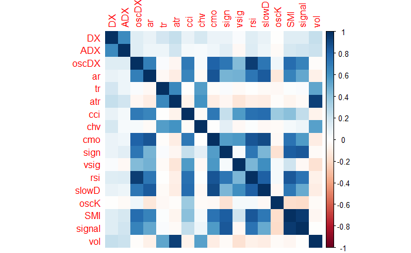

```r
corrplot(descCor, method="color")
```

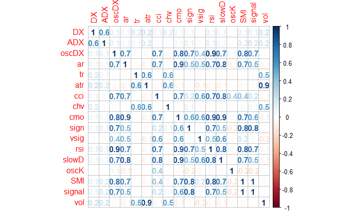

```r
corrplot(descCor, method="number", number.digits= 1)
```

9. Use the `findCorrelation` function from the `caret` package to find input variables have correlation above 90%.

```
[1] 12 15 17
```

10. create dataset without these variables and compute the correlation of the remaining ones.

| .rownames | DX | ADX | oscDX | ar | tr | atr | cci | chv | cmo | sign | vsig | slowD | oscK | signal |
| --- | --- | --- | --- | --- | --- | --- | --- | --- | --- | --- | --- | --- | --- | --- |
| DX | 1.000 | 0.639 | 0.137 | 0.097 | 0.186 | 0.232 | 0.091 | 0.175 | 0.087 | 0.089 | 0.028 | 0.098 | -0.005 | 0.138 |
| ADX | 0.639 | 1.000 | 0.139 | 0.079 | 0.070 | 0.193 | 0.049 | 0.039 | 0.068 | 0.130 | -0.038 | 0.073 | -0.023 | 0.197 |
| oscDX | 0.137 | 0.139 | 1.000 | 0.689 | 0.028 | -0.040 | 0.708 | 0.037 | 0.803 | 0.726 | 0.433 | 0.722 | 0.062 | 0.669 |
| ar | 0.097 | 0.079 | 0.689 | 1.000 | -0.038 | -0.091 | 0.658 | -0.030 | 0.855 | 0.467 | 0.480 | 0.838 | -0.124 | 0.510 |
| tr | 0.186 | 0.070 | 0.028 | -0.038 | 1.000 | 0.644 | -0.009 | 0.554 | -0.017 | 0.028 | -0.023 | -0.028 | -0.033 | 0.027 |
| atr | 0.232 | 0.193 | -0.040 | -0.091 | 0.644 | 1.000 | -0.064 | 0.590 | -0.095 | -0.043 | -0.133 | -0.094 | -0.018 | -0.021 |

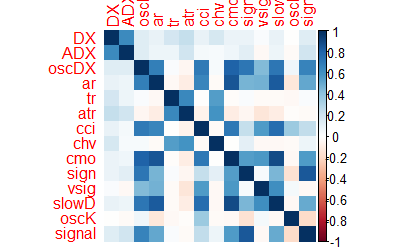

[figure not shown]

11. Divide the data set `data.f` without the highly correlated variables into a training and testing sets with ratio 2/3, normalize in the range of -1;1 and test the model. For separation use the rminer::holdout() function (like in the course, see also the help function) which will divide the set in two. For normalization we use the `caret::preProcess()` function and the method = c(“spatialSign”), see the help function. ( The spatial sign of a vector $w$ is $w /norm(w)$.)

12. Create a training set and test set using the predict fuunction from `rminer` (see course) and run a `randomUniformForest` model.

13. Investigate the global importance of predictors by runing the `summary` to the fitted object.

14. If we stop right here, which is normally offered by many R packages, we would have to select several predictors with the best indicators of global importance. This choice does not provide good results as it does not take into account the mutual influence of the predictors.
- run the help function for the `importance` method of the `randomUniformForest`
- run the `importance` function on the fitted object and the test set and `maxInteractions = 3`

- Compare the importance of variables on the basis of interaction with the global importance.
- Investiagte the importance of variables by classes taking into account their contribution and involvement.
- What about *tr*?
15. Check the model’s quality with the set of the 10 most important predictors and comapare it with the model with all variables.

15. Repeat the analysis (variable imporatnce) of the input variables in the optimal set.